# Wild Fires - Practical Assignment

Sofia Malpique & Yannik Bauer

#### Little note:

##### You can either load WildFires.RData, which has all the data that our report generated; or run the report line by line.

# Introduction

##### In this practical assignment we had the opportunity to get to know better some of the data mining tasks such as data cleaning, pre-processing, exploratory analysis, which includes data visualization and predictive modelling.

##### It was our job to combine different data-sets containing relevant information about wild fires in Portugal in order to come up with a machine learning model that would tell us if a certain fire was intentional or unintentional.

##### This report contains all the steps we took, our source code and some comments to help follow our thinking.

##### First, we should load all the necessary libraries:

```r
library(tidyverse)
library(dplyr)
library(dlookr)
library(rnoaa)
library(lubridate)
require(devtools)
library(zoo)
library(data.table)
library(ggplot2)
library(cluster)
library(fpc)
library(factoextra)
library(caret)
library(naivebayes)
library(rpart)
library(rpart.plot)
library(randomForest)
library(e1071)
library(nnet)
library(neuralnet)
library(caret)
library(performanceEstimation)
```

# Data importing, cleaning and pre-processing

```r
fires_train <- read_csv("fires_train.csv", na=c("-","NA"))
```

##### Given that no data related to temperature was available in our main data-set, we decided that it would be relevant and so, we imported it from another data-set.

```r
load("station_data.Rdata")
```

##### We are only interested in the main-land of Portugal, that’s why Azores and Madeira are not accounted. So we restrained to the coordinates of Portugal. Also, we have element == “TMAX”, because we are interested in using the maximum temperature registered on that day; and we select “id” and “name” because nothing else is relevant. We only want one temperature per district, so we removed “COIMBRA/CERNACHE” and “TAVIRA”.

```r
station_data <- station_data %>%
  filter(str_starts(id,"PO"), latitude < 42.2, latitude > 36.8,
         longitude > -9.6,longitude < -6.1, element=="TMAX") %>%
  select(id,name) %>%
  filter(name!="COIMBRA/CERNACHE",name!="TAVIRA")
```

##### We restrained the dates - we’re only interested in 2014 and 2015 and maintain “id” so we are able to join tables later. Then, sorted first by id and then by date to fill the missing values for “tmax”.

```r
weather_data <- ghcnd_search(station_data$id, var = c("TMAX"),
                             date_min = "2014-01-01", date_max = "2015-12-31")

weather_data <- weather_data$tmax %>%
  select(id,tmax,date) %>%
  arrange(id,date) %>%
  fill(tmax)
```

##### We want to find out which stations in Portugal have data on tmax. As we don’t have all the Portugal’s districts in “station_data” we need to add/create a column called “nearest_district” containing the districts available in “weather_data”. With this we can put the values of maximum temperature to districts that don’t appear in “weather_data” using the values of the nearest district.

```r
merge(weather_data,station_data,"id") %>% distinct(id, .keep_all = TRUE) %>%
  select(id,name)
```

| id | name |
| --- | --- |
| PO000008535 | LISBOA GEOFISICA |
| PO000008575 | BRAGANCA |
| POM00008554 | FARO |
| POM00008558 | EVORA/C. COORD |
| POM00008570 | CASTELO BRANCO |

```r
station_data <- station_data %>%
  mutate(nearest_district=c("Lisboa","Porto","Coimbra","Beja","Bragança","Faro",
                            "Évora","Castelo Branco")) %>%
  add_row(nearest_district="Viseu",id="PO000008575")  %>%
  add_row(nearest_district="Aveiro",id="PO000008575") %>%
  add_row(nearest_district="Braga",id="PO000008575")  %>%
  add_row(nearest_district="Viana do Castelo",id="PO000008575") %>%
  add_row(nearest_district="Vila Real",id="PO000008575") %>%
  add_row(nearest_district="Guarda",id="POM00008570") %>%
  add_row(nearest_district="Leiria",id="PO000008535") %>%
  add_row(nearest_district="Santarém",id="PO000008535") %>%
  add_row(nearest_district="Portalegre",id="POM00008558") %>%
  add_row(nearest_district="Setúbal",id="PO000008535")
station_data$id[2] <- "PO000008575"
station_data$id[3] <- "POM00008570"
station_data$id[4] <- "POM00008558"
```

```r
temp_data <- merge(station_data,weather_data,"id",all.x = TRUE) %>%
  as_tibble(.) %>%
  select(nearest_district,tmax,date) %>%
  rename(district=nearest_district) %>%
  mutate(tmax= (tmax/10))
```

##### Data understanding and analysis:

```r
fires_train
summary(fires_train)
spec(fires_train)
fires_train %>% find_na(index=FALSE)
fires_train %>% select(find_na(.)) %>% diagnose()
unique(select(fires_train,district))
```

##### We have created a data_preprocessing function for our fires_train and fires_test data-sets, that takes out alert_source because it only contained NA’s. Also we deleted the attributes municipality, parish, lat, lon, region, firstInterv_date, firstInterv_hour, extinction_date and extinction_hour because we thought they were not relevant. The attributes total_area and village_veget_area were as well removed because they are a linear combination of the remaining area attributes, therefore, redundant.

##### This function corrects the two instances of Viana do Castelo, that were differently written, converts alert_date orinigal type (dttm) into date. Merges the data-set with tmax creating new columns that we believe that can contribute better to the prediction task, such as season, timeOfDay, inLitoral and weekday.

```r
getSeason <- function(DATES) {
  WS <- as.Date("2012-12-21", format = "%Y-%m-%d") # Winter Solstice
  SE <- as.Date("2012-3-21",  format = "%Y-%m-%d") # Spring Equinox
  SS <- as.Date("2012-6-21",  format = "%Y-%m-%d") # Summer Solstice
  FE <- as.Date("2012-9-23",  format = "%Y-%m-%d") # Fall Equinox

  # Convert dates from any year to 2012 dates
  d <- as.Date(strftime(DATES, format="2012-%m-%d"))

  ifelse (d >= WS | d < SE, "Winter",
          ifelse (d >= SE & d < SS, "Spring",
                  ifelse (d >= SS & d < FE, "Summer", "Fall")))
}


data_preprocessing <- function(dataset){
  dataset <- dataset %>%
    select(-c(municipality,parish,alert_source,lat,lon,region,
              firstInterv_date,firstInterv_hour,total_area,village_veget_area,
              extinction_date,extinction_hour)) %>%
    mutate(district=replace(district,
                            district=="Viana Do Castelo","Viana do Castelo")) %>%
    mutate(alert_date=as.Date(alert_date)) %>%
    mutate(date=alert_date) %>%
    merge(temp_data,.,c("district","date"), all.y = TRUE) %>%
    as_tibble(.)
  dataset %>% find_na(index=FALSE)
  help <- dataset %>% subset(is.na(tmax)) %>%
    select(district,date,tmax)
  temp_data <- temp_data %>% add_row(help) %>%
    arrange(district,date) %>%
    fill(tmax) %>%
    unique(.)
  dataset <- dataset %>%
    select(-c(tmax)) %>%
    merge(temp_data,.,c("district","date")) %>%
    as_tibble(.) %>%
    rename(season = date) %>%
    mutate(season = getSeason(season), weekday = as.factor(weekdays(alert_date))) %>%
    mutate(weekday = ordered(weekday, levels=c("Monday","Tuesday","Wednesday",
                                               "Thursday","Friday","Saturday","Sunday")))
  litoral <- c("Viana do Castelo","Braga","Porto","Aveiro","Coimbra","Leiria",
               "Lisboa","Setúbal","Faro")
  time <- as.POSIXct(strptime(dataset$alert_hour,"%H:%M:%S"),"UTC")
  x=as.POSIXct(strptime(c("000000","060000","120000","180000","235959"),"%H%M%S"),
               "UTC")
  labs=c("dawn","morning","afternoon","night")
  dataset <- dataset %>%
    mutate(inLitoral=ifelse(district %in% litoral, 1,0),
           timeOfDay=labs[findInterval(time,x)])
  return(dataset)
}
```

##### Given that fires_test does not have intentional_cause attribute, we seperatly convert intentional_cause into factor type.

```r
fires_train <- data_preprocessing(fires_train) %>%
  mutate(intentional_cause=as.factor(intentional_cause))
```

# Data exploratory analysis

### How many intentional and non intentional fires do we have?

```r
fires_train %>% group_by(intentional_cause) %>% count()
```

| intentional_cause | n |
| --- | --- |
| 0 | 7389 |
| 1 | 2920 |

### Is there a different distribution according to the season for intentional and non-intentional fires?

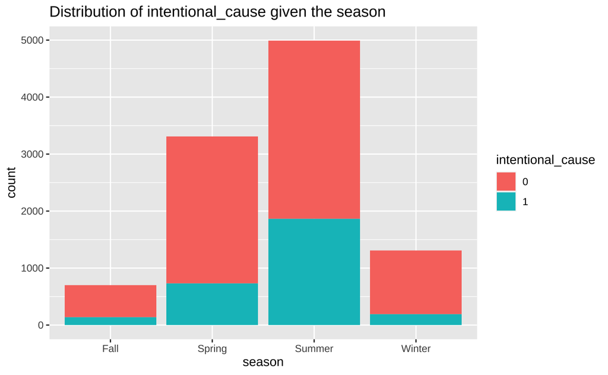

```r
ggplot(fires_train, aes(x=season,fill= intentional_cause)) + geom_bar() +
  ggtitle("Distribution of intentional_cause given the season")
```

##### As it was expected, most of the fires, intentional or unintentional, occured during summer. But, we noticed that there were more fires, intentional or unintentional, during the winter than during the fall, which is odd, and the difference isn’t that big when it comes to intentional fires.

### Is there a different distribution according to the weekday for intentional and non-intentional fires?

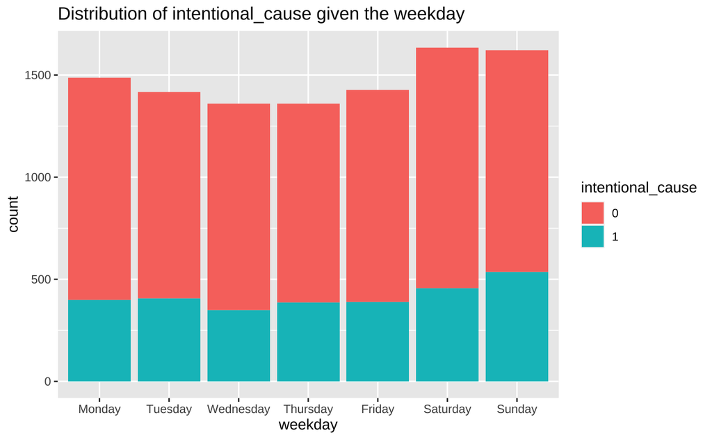

```r
ggplot(fires_train, aes(x=weekday,fill= intentional_cause)) + geom_bar() +
  ggtitle("Distribution of intentional_cause given the weekday")
```

##### We expected for the unintentional fires to be equally disttributed during the weedays, which didn’t happen. But for the intentional ones, we noticed that sunday is the day that most fires occur, which makes sense, given that sunday is the most common day-off in Portugal.

### Is there a different distribution according to the time of day for intentional and non-intentional fires?

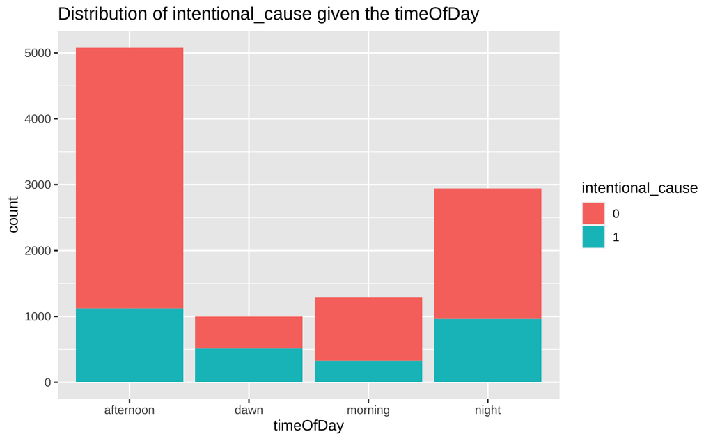

```r
ggplot(fires_train, aes(x=timeOfDay,fill= intentional_cause)) + geom_bar() +
  ggtitle("Distribution of intentional_cause given the timeOfDay")
```

##### As we can see, the majority of the fires happened during afternoon and night, the unintentional ones occur the most during the afternoon, but for the intentional ones, they’re pretty much occur nearlly equally during the afternoon and night.

### Could there be a relationship between “intentional_cause” and the maximum temperature?

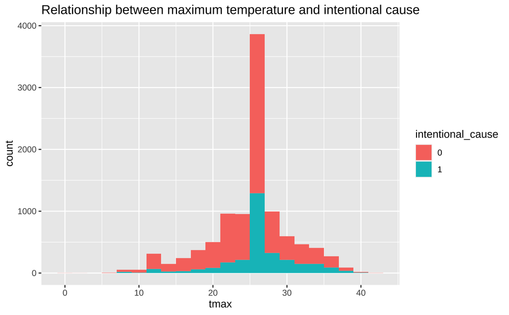

```r
ggplot(fires_train, aes(x=tmax, fill= intentional_cause)) + geom_histogram(binwidth = 2) +
  ggtitle("Relationship between maximum temperature and intentional cause")
```

##### It seems there is not a big difference disttribution for intentional and non-intentional fires.

### Could there be a relationship between “intentional_cause” and the time it was alerted?

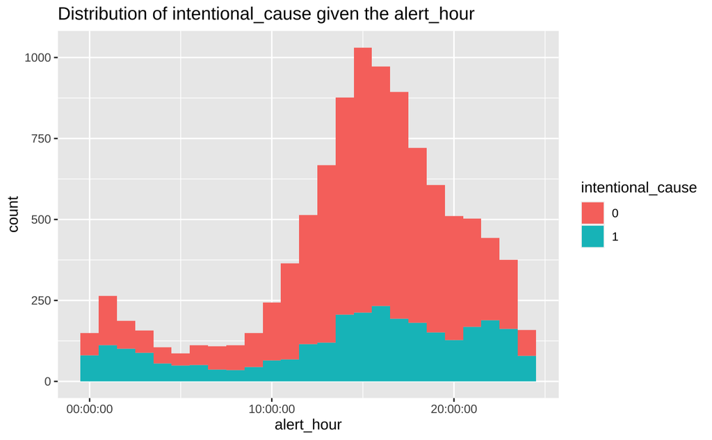

```r
ggplot(fires_train, aes(x=alert_hour, fill= intentional_cause)) +
  geom_histogram(binwidth = 3600) + scale_x_time() +
  ggtitle("Distribution of intentional_cause given the alert_hour")
```

##### The unintentional fires tend to happen the most between 10h and 22h, but it’s clear that theres is a spike arround 15h. On the other hand, the intentional ones, also occur between 10h and 22h, but their count is way more even between these hours - they do not have a spike.

### What can we say about the “origin” and the “intentional_cause”?

```r
fires_train %>% group_by(origin,intentional_cause) %>% count() %>%
  arrange(desc(n))
```

| origin | intentional_cause | n |
| --- | --- | --- |
| firepit | 0 | 3879 |
| firepit | 1 | 1896 |
| agriculture | 0 | 1730 |
| fire | 0 | 1284 |
| fire | 1 | 675 |
| agric_burn | 0 | 490 |
| agriculture | 1 | 344 |
| false_alarm | 0 | 6 |
| agric_burn | 1 | 3 |
| false_alarm | 1 | 2 |

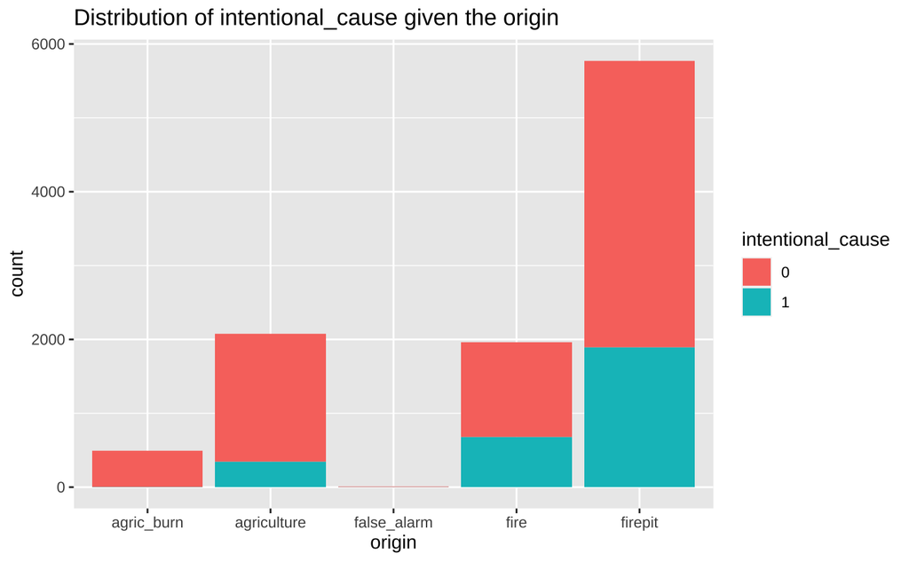

```r
ggplot(fires_train, aes(x=origin, fill= intentional_cause)) + geom_bar() +
  ggtitle("Distribution of intentional_cause given the origin")
```

### What is the correlation coefficient between all numeric attributes?

```r
fires_train %>% select(tmax,village_area, farming_area,
                 vegetation_area) %>% cor()
```

```
                      tmax village_area farming_area vegetation_area
tmax            1.00000000    0.0330801   0.05712894      0.02481804
village_area    0.03308010    1.0000000   0.52373493      0.30648934
farming_area    0.05712894    0.5237349   1.00000000      0.20320319
vegetation_area 0.02481804    0.3064893   0.20320319      1.00000000
```

### Is there any monotonic relationship?

```r
fires_train %>% select(tmax,village_area, farming_area,
                 vegetation_area) %>% cor(method = "spearman")
```

```
                       tmax village_area farming_area vegetation_area
tmax             1.00000000  -0.02875831    0.1917000     -0.17534685
village_area    -0.02875831   1.00000000   -0.2429557     -0.06075794
farming_area     0.19170002  -0.24295569    1.0000000     -0.51480894
vegetation_area -0.17534685  -0.06075794   -0.5148089      1.00000000
```

# Predictive Modeling

```r
fires_test <- read_csv("fires_test.csv", na=c("-","NA"))
fires_test <- data_preprocessing(fires_test)
```

##### We wanted to try the preditive modelling task with normalized data and not-normalized data so we could compare the outcomes in order to decide which were better.

##### Therefore, we created the following function:

```r
normalize <- function(x) {
  return ((x - min(x,na.rm=TRUE)) / (max(x,na.rm=TRUE) - min(x,na.rm=TRUE)))
}

normalize_data <- function(dataset){
  dataset <- dataset %>%
    mutate(tmax=normalize(tmax),
           farming_area=normalize(farming_area),
           village_area=normalize(village_area),
           vegetation_area=normalize(vegetation_area)) %>%
    mutate(firepit=ifelse(origin=="firepit",1,0),
           fire=ifelse(origin=="fire",1,0),
           agriculture=ifelse(origin=="agriculture",1,0),
           agric_burn=ifelse(origin=="agric_burn",1,0),
           false_alarm=ifelse(origin=="false_alarm",1,0)) %>%
    mutate(winter=ifelse(season=="Winter",1,0),
           spring=ifelse(season=="Spring",1,0),
           summer=ifelse(season=="Summer",1,0),
           fall=ifelse(season=="Fall",1,0)) %>%
    mutate(Monday=ifelse(weekday=="Monday",1,0),
           Tuesday=ifelse(weekday=="Tuesday",1,0),
           Wednesday=ifelse(weekday=="Wednesday",1,0),
           Thursday=ifelse(weekday=="Thursday",1,0),
           Friday=ifelse(weekday=="Friday",1,0),
           Saturday=ifelse(weekday=="Saturday",1,0),
           Sunday=ifelse(weekday=="Sunday",1,0)) %>%
    mutate(dawn=ifelse(timeOfDay=="dawn",1,0),
           afternoon=ifelse(timeOfDay=="afternoon",1,0),
           night=ifelse(timeOfDay=="night",1,0),
           morning=ifelse(timeOfDay=="morning",1,0)) %>%
    mutate(alert_date=gsub("[: -]","",alert_date),
           alert_hour=gsub("[: -]","",alert_hour)) %>%
    mutate(alert_date=normalize(as.numeric(alert_date)),
           alert_hour=normalize(as.numeric(alert_hour))) %>%
    select(-c(origin,season,weekday,timeOfDay))
  return(dataset)
}
```

```r
id <- fires_test %>% select(id)
fires_test <- fires_test %>% select(-id)
fires_train <- fires_train %>% select(-id)
fires_train_norm <- normalize_data(fires_train)
fires_test_norm <- normalize_data(fires_test)
fires_train_norm <- fires_train_norm %>% select(-district)
fires_test_norm <- fires_test_norm %>% select(-district)
```

##### We are testing different models with normalized data and with not-normalized data, in order to find the best predictive model.

```r
res <- performanceEstimation(PredTask(intentional_cause ~ ., fires_train),
                             c(Workflow(learner = "naiveBayes"),
                               workflowVariants(learner = "rpart",
                                                learner.pars = list(maxdepth = c(3,5)),
                                                predictor.pars = list(type = "class")),
                               Workflow(learner = "rpart", predictor.pars = list(type = "class")),
                               Workflow(learner = "randomForest",
                                        learner.pars = list(na.action=na.omit,importance=T)),
                               Workflow(learner = "nnet",
                                        learner.pars = list(size = 5),
                                        predictor.pars = list(type = "class"))),
                             EstimationTask(metrics = c("acc", "F", "rec", "prec")))


res_norm <- performanceEstimation(PredTask(intentional_cause ~ ., fires_train_norm),
                                  c(Workflow(learner = "naiveBayes"),
                                    workflowVariants(learner = "knn3",
                                                     learner.pars = list(k=c(3,5,7)),
                                                     predictor.pars = list(type = "class")),
                                    workflowVariants(learner = "rpart",
                                                     learner.pars = list(maxdepth = c(3,5)),
                                                     predictor.pars = list(type = "class")),
                                    Workflow(learner = "rpart",
                                             predictor.pars = list(type = "class")),
                                    Workflow(learner = "randomForest",
                                             learner.pars = list(na.action=na.omit,importance=T)),
                                    workflowVariants(learner = "svm",
                                                     learner.pars = list(kernel = "radial"),
                                                     predictor.pars = list(type = "class")),
                                    Workflow(learner = "nnet",
                                             learner.pars = list(size = 5),
                                             predictor.pars = list(type = "class"))),
                                  EstimationTask(metrics = c("acc", "F", "rec", "prec")))
```

```r
rankWorkflows(res_norm, max = TRUE)
```

```
$fires_train_norm.intentional_cause
$fires_train_norm.intentional_cause$acc
```

|  | Workflow | Estimate |
| --- | --- | --- |
| 1 | randomForest | 0.7433981 |
| 2 | svm | 0.7345631 |
| 3 | nnet | 0.7284466 |
| 4 | rpart.v2 | 0.7234951 |
| 5 | rpart | 0.7234951 |

```
$fires_train_norm.intentional_cause$F
```

|  | Workflow | Estimate |
| --- | --- | --- |
| 1 | randomForest | 0.8363571 |
| 2 | svm | 0.8363350 |
| 3 | nnet | 0.8302422 |
| 4 | rpart.v2 | 0.8267070 |
| 5 | rpart | 0.8267070 |

```
$fires_train_norm.intentional_cause$rec
```

|  | Workflow | Estimate |
| --- | --- | --- |
| 1 | svm | 0.9473217 |
| 2 | nnet | 0.9277533 |
| 3 | rpart.v2 | 0.9211199 |
| 4 | rpart | 0.9211199 |
| 5 | randomForest | 0.9156322 |

```
$fires_train_norm.intentional_cause$prec
```

|  | Workflow | Estimate |
| --- | --- | --- |
| 1 | naiveBayes | 0.8133642 |
| 2 | randomForest | 0.7700323 |
| 3 | knn3.v1 | 0.7620226 |
| 4 | knn3.v2 | 0.7597386 |
| 5 | knn3.v3 | 0.7573400 |

```r
rankWorkflows(res, max = TRUE)
```

```
$fires_train.intentional_cause
$fires_train.intentional_cause$acc
```

|  | Workflow | Estimate |
| --- | --- | --- |
| 1 | randomForest | 0.7560194 |
| 2 | rpart.v2 | 0.7405825 |
| 3 | rpart | 0.7405825 |
| 4 | rpart.v1 | 0.7274757 |
| 5 | naiveBayes | 0.7224272 |

```
$fires_train.intentional_cause$F
```

|  | Workflow | Estimate |
| --- | --- | --- |
| 1 | randomForest | 0.8429027 |
| 2 | rpart.v2 | 0.8350582 |
| 3 | rpart | 0.8350582 |
| 4 | rpart.v1 | 0.8335380 |
| 5 | nnet | 0.8294511 |

```
$fires_train.intentional_cause$rec
```

|  | Workflow | Estimate |
| --- | --- | --- |
| 1 | nnet | 0.9636289 |
| 2 | rpart.v1 | 0.9520887 |
| 3 | naiveBayes | 0.9426554 |
| 4 | rpart.v2 | 0.9169123 |
| 5 | rpart | 0.9169123 |

```
$fires_train.intentional_cause$prec
```

|  | Workflow | Estimate |
| --- | --- | --- |
| 1 | randomForest | 0.7821141 |
| 2 | rpart.v2 | 0.7669619 |
| 3 | rpart | 0.7669619 |
| 4 | rpart.v1 | 0.7429233 |
| 5 | naiveBayes | 0.7408117 |

```
NANA
```

##### We conclude that the model randomForest is the one that has better scores and results, so this is the one we’re going with! Also note that the better results come with not-normalized data.

##### Now we are evaluating which attributes can give us a better score.

```r
fires_train_eval <- fires_train

a1 <- performanceEstimation(PredTask(intentional_cause ~ ., fires_train_eval),
                             c(Workflow(learner = "randomForest",
                                        learner.pars = list(na.action=na.omit,
                                                            importance=T))),
                             EstimationTask(metrics = c("acc", "F", "rec", "prec")))
```

```r
summary(a1)
```

```
== Summary of a  Cross Validation Performance Estimation Experiment ==

Task for estimating  acc,F,rec,prec  using
 1 x 10 - Fold Cross Validation
     Run with seed =  1234

* Predictive Tasks ::  fires_train_eval.intentional_cause
* Workflows  ::  randomForest

-> Task:  fires_train_eval.intentional_cause
  *Workflow: randomForest
               acc          F        rec       prec
avg     0.75601942 0.84290269 0.91437837 0.78211412
std     0.01647659 0.01236359 0.01633316 0.01887552
med     0.75679612 0.84329463 0.91230123 0.78310659
iqr     0.02475728 0.01720315 0.02299920 0.02839554
min     0.72912621 0.82263191 0.89271523 0.75055928
max     0.77864078 0.86192469 0.94109397 0.80648770
invalid 0.00000000 0.00000000 0.00000000 0.00000000
```

```r
fires_train_eval <- fires_train %>% select(-timeOfDay)

a2 <- performanceEstimation(PredTask(intentional_cause ~ ., fires_train_eval),
                             c(Workflow(learner = "randomForest",
                                        learner.pars = list(na.action=na.omit,
                                                            importance=T))),
                             EstimationTask(metrics = c("acc", "F", "rec", "prec")))
```

```r
summary(a2)
```

```
== Summary of a  Cross Validation Performance Estimation Experiment ==

Task for estimating  acc,F,rec,prec  using
 1 x 10 - Fold Cross Validation
     Run with seed =  1234

* Predictive Tasks ::  fires_train_eval.intentional_cause
* Workflows  ::  randomForest

-> Task:  fires_train_eval.intentional_cause
  *Workflow: randomForest
               acc          F        rec       prec
avg     0.75786408 0.84383608 0.91419016 0.78385668
std     0.01769727 0.01354623 0.01895778 0.01848129
med     0.75728155 0.84320537 0.91229661 0.78808772
iqr     0.02548544 0.01689550 0.02915000 0.02602843
min     0.73203883 0.82397959 0.88741722 0.75000000
max     0.78446602 0.86785714 0.94249649 0.80910100
invalid 0.00000000 0.00000000 0.00000000 0.00000000
```

```r
fires_train_eval <- fires_train %>% select(-c(season,timeOfDay))

a3 <- performanceEstimation(PredTask(intentional_cause ~ ., fires_train_eval),
                             c(Workflow(learner = "randomForest",
                                        learner.pars = list(na.action=na.omit,
                                                            importance=T))),
                             EstimationTask(metrics = c("acc", "F", "rec", "prec")))
```

```r
summary(a3)
```

```
== Summary of a  Cross Validation Performance Estimation Experiment ==

Task for estimating  acc,F,rec,prec  using
 1 x 10 - Fold Cross Validation
     Run with seed =  1234

* Predictive Tasks ::  fires_train_eval.intentional_cause
* Workflows  ::  randomForest

-> Task:  fires_train_eval.intentional_cause
  *Workflow: randomForest
               acc          F        rec       prec
avg     0.75155340 0.83961116 0.90852803 0.78071877
std     0.01391548 0.01116792 0.01661463 0.01699790
med     0.75097087 0.83933561 0.90754020 0.78109801
iqr     0.01796117 0.01357613 0.02676903 0.02617461
min     0.73009709 0.82270408 0.88609272 0.75112613
max     0.77475728 0.86157518 0.93548387 0.80490524
invalid 0.00000000 0.00000000 0.00000000 0.00000000
```

```r
fires_train_eval <- fires_train %>% select(-c(inLitoral,timeOfDay))

a4 <- performanceEstimation(PredTask(intentional_cause ~ ., fires_train_eval),
                             c(Workflow(learner = "randomForest",
                                        learner.pars = list(na.action=na.omit,
                                                            importance=T))),
                             EstimationTask(metrics = c("acc", "F", "rec", "prec")))
```

```r
summary(a4)
```

```
== Summary of a  Cross Validation Performance Estimation Experiment ==

Task for estimating  acc,F,rec,prec  using
 1 x 10 - Fold Cross Validation
     Run with seed =  1234

* Predictive Tasks ::  fires_train_eval.intentional_cause
* Workflows  ::  randomForest

-> Task:  fires_train_eval.intentional_cause
  *Workflow: randomForest
               acc          F        rec       prec
avg     0.75592233 0.84255778 0.91221802 0.78303289
std     0.01448884 0.01099396 0.01386185 0.01703520
med     0.75970874 0.84526384 0.90934410 0.78410935
iqr     0.02135922 0.01517995 0.02094384 0.02763423
min     0.73203883 0.82442748 0.89502762 0.75452489
max     0.77669903 0.85748503 0.93548387 0.80359147
invalid 0.00000000 0.00000000 0.00000000 0.00000000
```

```r
fires_train_eval <- fires_train %>% select(-c(alert_date,timeOfDay))

a5 <- performanceEstimation(PredTask(intentional_cause ~ ., fires_train_eval),
                             c(Workflow(learner = "randomForest",
                                        learner.pars = list(na.action=na.omit,
                                                            importance=T))),
                             EstimationTask(metrics = c("acc", "F", "rec", "prec")))
```

```r
summary(a5)
```

```
== Summary of a  Cross Validation Performance Estimation Experiment ==

Task for estimating  acc,F,rec,prec  using
 1 x 10 - Fold Cross Validation
     Run with seed =  1234

* Predictive Tasks ::  fires_train_eval.intentional_cause
* Workflows  ::  randomForest

-> Task:  fires_train_eval.intentional_cause
  *Workflow: randomForest
               acc          F        rec       prec
avg     0.75194175 0.84018414 0.91121386 0.77968706
std     0.01608548 0.01270996 0.01887425 0.01607753
med     0.74708738 0.83672818 0.90540312 0.77707800
iqr     0.01699029 0.01381031 0.03081342 0.02396508
min     0.73106796 0.82390337 0.88476821 0.75623583
max     0.78252427 0.86698337 0.93709884 0.80662983
invalid 0.00000000 0.00000000 0.00000000 0.00000000
```

```r
fires_train_eval <- fires_train %>% select(-c(alert_hour,timeOfDay))

a6 <- performanceEstimation(PredTask(intentional_cause ~ ., fires_train_eval),
                             c(Workflow(learner = "randomForest",
                                        learner.pars = list(na.action=na.omit,
                                                            importance=T))),
                             EstimationTask(metrics = c("acc", "F", "rec", "prec")))
```

```r
summary(a6)
```

```
== Summary of a  Cross Validation Performance Estimation Experiment ==

Task for estimating  acc,F,rec,prec  using
 1 x 10 - Fold Cross Validation
     Run with seed =  1234

* Predictive Tasks ::  fires_train_eval.intentional_cause
* Workflows  ::  randomForest

-> Task:  fires_train_eval.intentional_cause
  *Workflow: randomForest
               acc          F        rec       prec
avg     0.73990291 0.83214299 0.90101978 0.77338350
std     0.01880061 0.01453596 0.01943409 0.01960284
med     0.73300971 0.82779582 0.89746967 0.77064018
iqr     0.02111650 0.01498830 0.02949811 0.01746921
min     0.71456311 0.81345178 0.87814570 0.74161074
max     0.77766990 0.86328358 0.92987377 0.80691964
invalid 0.00000000 0.00000000 0.00000000 0.00000000
```

```r
fires_train_eval <- fires_train %>% select(-c(timeOfDay,season,weekday,inLitoral))

a7 <- performanceEstimation(PredTask(intentional_cause ~ ., fires_train_eval),
                             c(Workflow(learner = "randomForest",
                                        learner.pars = list(na.action=na.omit,
                                                            importance=T))),
                             EstimationTask(metrics = c("acc", "F", "rec", "prec")))
```

```r
summary(a7)
```

```
== Summary of a  Cross Validation Performance Estimation Experiment ==

Task for estimating  acc,F,rec,prec  using
 1 x 10 - Fold Cross Validation
     Run with seed =  1234

* Predictive Tasks ::  fires_train_eval.intentional_cause
* Workflows  ::  randomForest

-> Task:  fires_train_eval.intentional_cause
  *Workflow: randomForest
               acc          F        rec       prec
avg     0.75087379 0.84198882 0.92734214 0.77127184
std     0.01218824 0.01014202 0.01496200 0.01546891
med     0.75194175 0.84173745 0.92790027 0.77276009
iqr     0.01553398 0.01272942 0.02262362 0.01688692
min     0.73495146 0.83092395 0.90596026 0.74122807
max     0.77378641 0.86382233 0.94865212 0.79291845
invalid 0.00000000 0.00000000 0.00000000 0.00000000
```

```r
a <- mergeEstimationRes(a1,a2,a3,a4,a5,a6,a7,by="workflows")
rankWorkflows(a, max = TRUE)
```

```
$fires_train_eval.intentional_cause
$fires_train_eval.intentional_cause$acc
```

|  | Workflow | Estimate |
| --- | --- | --- |
| 1 | randomForest | 0.7578641 |
| 2 | randomForest | 0.7560194 |
| 3 | randomForest | 0.7559223 |
| 4 | randomForest | 0.7519417 |
| 5 | randomForest | 0.7515534 |

```
$fires_train_eval.intentional_cause$F
```

|  | Workflow | Estimate |
| --- | --- | --- |
| 1 | randomForest | 0.8438361 |
| 2 | randomForest | 0.8429027 |
| 3 | randomForest | 0.8425578 |
| 4 | randomForest | 0.8419888 |
| 5 | randomForest | 0.8401841 |

```
$fires_train_eval.intentional_cause$rec
```

|  | Workflow | Estimate |
| --- | --- | --- |
| 1 | randomForest | 0.9273421 |
| 2 | randomForest | 0.9143784 |
| 3 | randomForest | 0.9141902 |
| 4 | randomForest | 0.9122180 |
| 5 | randomForest | 0.9112139 |

```
$fires_train_eval.intentional_cause$prec
```

|  | Workflow | Estimate |
| --- | --- | --- |
| 1 | randomForest | 0.7838567 |
| 2 | randomForest | 0.7830329 |
| 3 | randomForest | 0.7821141 |
| 4 | randomForest | 0.7807188 |
| 5 | randomForest | 0.7796871 |

```
NANA
```

##### After these resuts, we conclude that we have better scores if we remove “timeOfDay” from the final data-set.

```r
fires_train_final <- select(fires_train,-c(timeOfDay))
fires_test_final <- select(fires_test,-c(timeOfDay))
```

```r
randomForest_model <- randomForest(intentional_cause ~ ., fires_train_final)
randomForest_preds <- predict(randomForest_model, fires_test_final)
```

##### Now we are creating the csv file to submit on Kaggle.

```r
result <- id %>% mutate(intentional_cause=randomForest_preds) %>% arrange(id)
write.csv(result,file="result.csv",row.names = FALSE)
```